# Winter Habitat Use by Common Loons (Gavia Immer)

on Mount Desert Island, Maine

Ellie Gabrielson, Will Draxler, Autumn Pauly

03/12/2024

# Background Information

## Introduction

Although Common Loons (Gavia immer) have been studied extensively during the breeding season not much is known of their behavior on their ocean wintering grounds, where Loons spend a significant part of their lives (Bent, 2009). The few studies that do look at winter behavior often yield conflicting results (McIntyre, 1978; Daub, 1989; Ford and Gieg, 1995). The possible use of different shoreline habitats for activities such as feeding, sleeping, or taking shelter is worthy of study. McIntyre (1978) found common loons were semi-social and formed loose rafts and that loon behavior varied with tides, weather, and time of day. Daub (1989) and later Ford and Gieg (1995) found refuting evidence suggesting loons were neither social nor territorial, and did not change their behavior much by tide. Holm and Burger (2002) found that the general pattern for loons was that they foraged during slack and main-flow water. Additionally, the possible difference in dive times as a result of varying tidal heights is worthy of study. Thompson and Price (2006) observed that dive times were longer during low tide in comparison to other tidal stages, though more studies should be conducted to assess the use of tidal stage and behavior.

Our general hypothesis when analyzing this data is that environmental conditions affect the behavior of the *G. immer*. The null hypothesis to this statement is that environmental conditions do not affect the behavior of the *G. immer*.

## Methods

In 2023, observations were conducted at nine established observation sites along the coastline of Mount Desert Island in Hancock County (Maine). Observations occurred from January 2023 to March 2023 on a biweekly basis, where each waterfowl individual was recorded as well as their behaviors, referencing Daub’s (1989) list of behaviors, and coordinate location. Locational coordinates were obtained by estimating the individual’s rough location digitally (accurate to + or - 10 m). Each transect site was visited for roughly 5-10 minutes, where data collection followed initial observation. Utilizing a Kestrel 2500, weather data was recorded accurately to + or - 1°C of temperatures and within 3% of wind speed. Referencing Daub’s (1989) list of behaviors, each species’ behavior during the observation was noted. The weather and environmental data recorded included wind speed and direction, barometer, cloud cover, precipitation, humidity, temperature, tidal percentage, and wave class (Beaufort Wind Speed). Tidal data was gathered from NOAA’s digital tidal charts. This study was repeated in 2024 with the addition of observational variables including species dive times and tidal height.

# Data Analysis

## Load Packages and Data

```r
#install.packages("tidyverse")
library(tidyverse)
library(rmarkdown)
library(scales)
library(ggridges)
library(rstatix)
library(parsnip)
```

```r
loons_2023 <- read_csv("loon_2023_tidy.csv")
loons_2024 <- read_csv("loon_2024_tidy.csv")
```

## Tidal Condition and Behavior for 2023

The first analysis that will be conducted will be investigating the potential relationship between tidal condition and *G. immer* behavior. As was stated above, the behaviors chosen are referencing Daub’s (1989) list of behaviors. The tidal condition was sorted into three categories: `high`, `mid`, and `low`.

Hypothesis: Tidal height has a significant effect on *G. immer* behavior Null Hypothesis: Tidal height will not have a significant effect on *G. immer* behavior

The null hypothesis for this analysis suggests that behaviors of Common Loons will be dependent of tidal condition, whilst the hypothesis suggests the opposite.

### Statistics

#### Chi-Squared Test of Independence

The Chi-Squared Test of Independence examines whether there is a relationship between two categorical variables. Our null hypothesis, that tidal height will not have a significant effect on *G. immer* behavior, assumes that tidal condition and behavior are independent. Our hypothesis, that tidal height will have a significant effect on *G. immer* behavior, assumes that tidal condition and behavior are dependent.

#### Expected Frequencies and Contingency Table

Before performing the chi-square test, we need to calculate the expected frequencies for each cell in the contingency table. These expected frequencies represent what you would expect to observe if there were no association between tidal condition and behavior.

```
##
##        ASHORE DIVING DRIFTING MAINTENANCE PEERING
##   HIGH      0     23        7           2       1
##   LOW       1     38       26           1       2
##   MID       0     29        0           0       1
```

#### Chi-square Test

Now that we have the contingency table of expected frequencies, we can perform the statistical test.

```
##
##  Pearson's Chi-squared test
##
## data:  contingency_table1
## X-squared = 21.276, df = 8, p-value = 0.006449
```

## Tidal Conditions and Dive Times in 2024

The second analysis that will be conducted will be investigating the potential relationship between tidal condition and *G. immer* dive times. The null hypothesis for this analysis suggests that dive times of *G. immer* will be dependent of tidal condition, whilst the hypothesis suggests the opposite.

Hypothesis: Low tide will cause *G. immer* to have significantly longer dive times. Null Hypothesis: Low tide will not cause *G. immer* to have significantly longer dive times.

### Visualizations

As can be seen below, we do not have a normal distribution for the variable `dive_time_obs`. We will need to perform a non-parametric test.

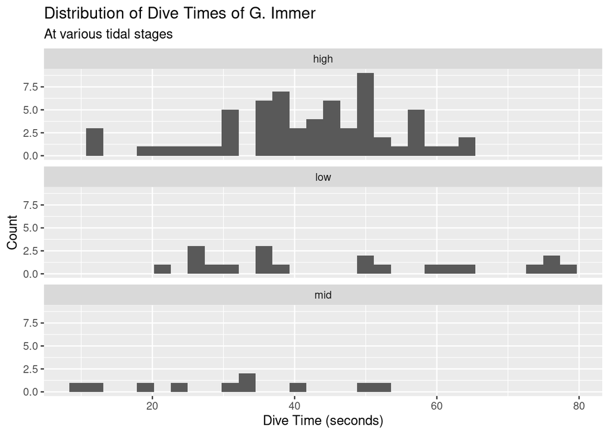

#### Statistics

The non-parametric nature of our dataset suggests that we need to use the Kruskal-Wallis H test (the “one-way ANOVA on ranks”), which is the non-parametric alternative to the one-way ANOVA test.

```
##
##  Kruskal-Wallis rank sum test
##
## data:  dive_time_obs by general_tide
## Kruskal-Wallis chi-squared = 5.8245, df = 2, p-value = 0.05435
```

```
## # A tibble: 3 × 9
##   .y.           group1 group2    n1    n2 statistic      p  p.adj p.adj.signif
## * <chr>         <chr>  <chr>  <int> <int>     <dbl>  <dbl>  <dbl> <chr>
## 1 dive_time_obs high   low       63    20     0.570 0.568  1      ns
## 2 dive_time_obs high   mid       63    10    -2.20  0.0276 0.0829 ns
## 3 dive_time_obs low    mid       20    10    -2.31  0.0207 0.0621 ns
```

[figure not shown]

REPORT: The dive times of *G. immer* does not differ significantly from various tidal stages (Kruskal-Wallis rank sum test; H(2) = 5.82, P = 0.054).

## Exposure Level and Abundance in 2023

The third analysis that will be conducted will be investigating the potential relationship between exposure level and *G. immer* abundance during the 2023 observation period. The null hypothesis for this analysis suggests that *G. immer* abundance will be independent of exposure level, whilst the hypothesis suggests the opposite.

Null Hypothesis: Higher exposure level of location will not significantly positively affect *G. immer* presence.

Hypothesis: Higher exposure level of location significantly positively affects *G. immer* presence.

### Visualizations

Below we are visualizing abundance in the form of boxplots.

As we can see below, it appears as though there is the highest abundance at locations that are exposed and the lowest abundance at locations that are sheltered. Statistical tests will need to be performed to see if there is a significant difference in the abundances at different exposure levels.

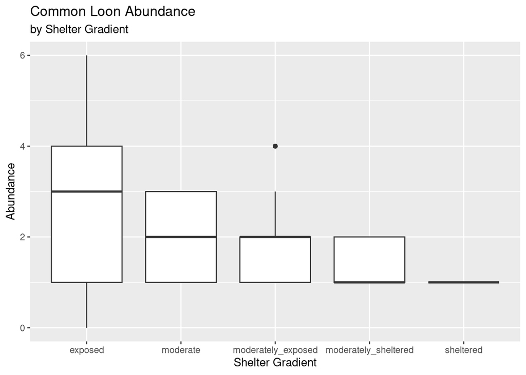

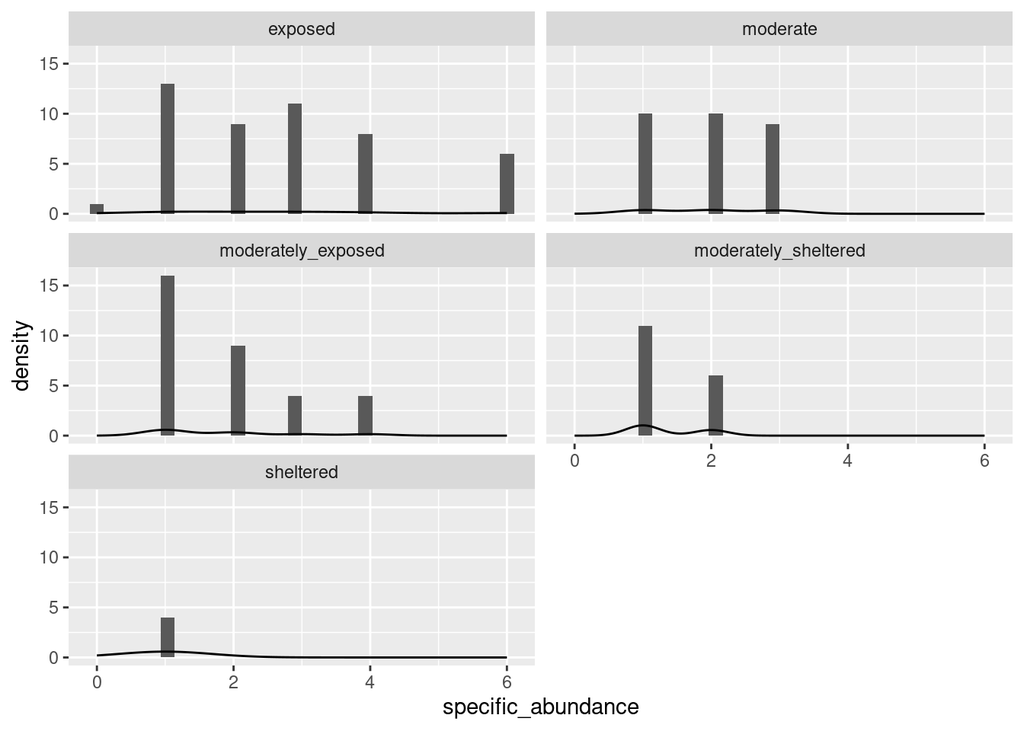

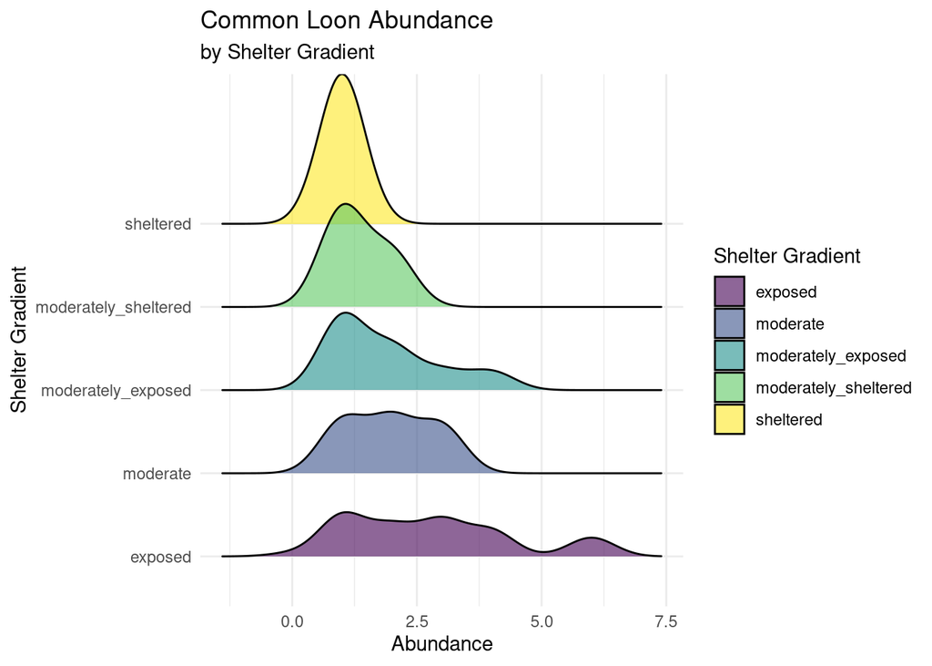

### Statistics

To determine if there is a significant difference in the abundance of *G. immer* in locations with varying exposure levels, where the exposure levels are categorical variable with five levels (exposed, moderately exposed, moderate, moderately sheltered, and sheltered), and the abundance is a continuous numerical variable, a one-way analysis of variance (ANOVA) will be used.

```r
abundanceexposureaov = aov(specific_abundance ~ shelter_gradient, data = loons_2023)
summary(abundanceexposureaov)
```

```
##                   Df Sum Sq Mean Sq F value   Pr(>F)
## shelter_gradient   4  36.68   9.171   6.167 0.000145 ***
## Residuals        126 187.36   1.487
## ---
## Signif. codes:  0 '***' 0.001 '**' 0.01 '*' 0.05 '.' 0.1 ' ' 1
```

```r
TukeyHSD(abundanceexposureaov)
```

```
##   Tukey multiple comparisons of means
##     95% family-wise confidence level
##
## Fit: aov(formula = specific_abundance ~ shelter_gradient, data = loons_2023)
##
## $shelter_gradient
##                                                diff        lwr          upr
## moderate-exposed                        -0.78448276 -1.5782588  0.009293261
## moderately_exposed-exposed              -0.87121212 -1.6344100 -0.108014250
## moderately_sheltered-exposed            -1.39705882 -2.3496002 -0.444517493
## sheltered-exposed                       -1.75000000 -3.5063994  0.006399428
## moderately_exposed-moderate             -0.08672936 -0.9457668  0.772308103
## moderately_sheltered-moderate           -0.61257606 -1.6435025  0.418350393
## sheltered-moderate                      -0.96551724 -2.7656321  0.834597568
## moderately_sheltered-moderately_exposed -0.52584670 -1.5334180  0.481724627
## sheltered-moderately_exposed            -0.87878788 -2.6656298  0.908054014
## sheltered-moderately_sheltered          -0.35294118 -2.2284859  1.522603529
##                                             p adj
## moderate-exposed                        0.0543970
## moderately_exposed-exposed              0.0166513
## moderately_sheltered-exposed            0.0008059
## sheltered-exposed                       0.0513347
## moderately_exposed-moderate             0.9986485
## moderately_sheltered-moderate           0.4720480
## sheltered-moderate                      0.5744390
## moderately_sheltered-moderately_exposed 0.6002795
## sheltered-moderately_exposed            0.6535007
## sheltered-moderately_sheltered          0.9851163
```

## Exposure Level and Behavior

The third analysis that will be conducted will be investigating the potential relationship between exposure level and *G. immer* behavior during the 2023 observation period. The null hypothesis for this analysis suggests that *G. immer* behavior will be independent of exposure level, whilst the hypothesis suggests the opposite.

Null Hypothesis: Exposure level of location has no significant impact on *G. immer* behavior.

Hypothesis: Exposure level of location significantly impacts *G. immer* behavior.

### Visualizations

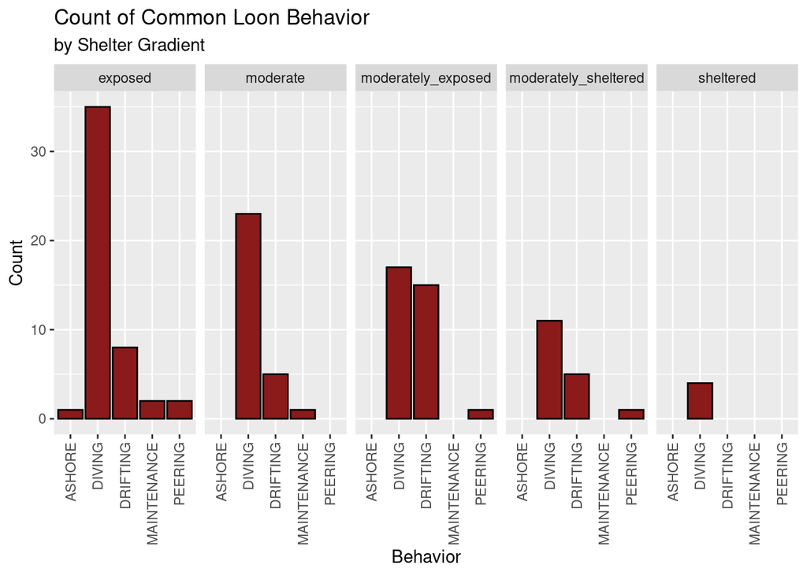

```r
loons_2023 %>%
  count(behavior, shelter_gradient) %>%
  ggplot(aes(x = behavior, y = n)) +
  geom_col(fill = "firebrick4", color = "black") +
  facet_wrap(~ shelter_gradient, nrow = 1) +
  theme(axis.text.x = element_text(angle = 90, vjust = 0.5, hjust=1)) +
  labs(title = "Count of Common Loon Behavior",
       subtitle = "by Shelter Gradient",
       x = "Behavior",
       y = "Count")
```

### Statistics

```
##
##  Kruskal-Wallis rank sum test
##
## data:  behavior by shelter_gradient
## Kruskal-Wallis chi-squared = 7.741, df = 4, p-value = 0.1015
```

```
## # A tibble: 10 × 9
##    .y.      group1        group2    n1    n2 statistic      p p.adj p.adj.signif
##  * <chr>    <chr>         <chr>  <int> <int>     <dbl>  <dbl> <dbl> <chr>
##  1 behavior exposed       moder…    48    29    -0.376 0.707  1     ns
##  2 behavior exposed       moder…    48    33     2.06  0.0389 0.389 ns
##  3 behavior exposed       moder…    48    17     0.793 0.428  1     ns
##  4 behavior exposed       shelt…    48     4    -1.00  0.317  1     ns
##  5 behavior moderate      moder…    29    33     2.18  0.0291 0.291 ns
##  6 behavior moderate      moder…    29    17     1.02  0.307  1     ns
##  7 behavior moderate      shelt…    29     4    -0.811 0.417  1     ns
##  8 behavior moderately_e… moder…    33    17    -0.815 0.415  1     ns
##  9 behavior moderately_e… shelt…    33     4    -1.87  0.0620 0.620 ns
## 10 behavior moderately_s… shelt…    17     4    -1.34  0.180  1     ns
```

#### Chi-Squared Test of Independence

The Chi-Squared Test of Independence examines whether there is a relationship between two categorical variables. Our null hypothesis, that exposure will not have a significant effect on *G. immer* behavior, assumes that exposure level and behavior are independent.

#### Expected Frequencies and Contingency Table

Before performing the chi-square test, we need to calculate the expected frequencies for each cell in the contingency table. These expected frequencies represent what you would expect to observe if there were no association between exposure and behavior.

```
##
##                        ASHORE DIVING DRIFTING MAINTENANCE PEERING
##   exposed                   1     35        8           2       2
##   moderate                  0     23        5           1       0
##   moderately_exposed        0     17       15           0       1
##   moderately_sheltered      0     11        5           0       1
##   sheltered                 0      4        0           0       0
```

#### Chi-square Test

Now that we have the contingency table of expected frequencies, we can perform the statistical test.

```
##
##  Pearson's Chi-squared test
##
## data:  contingency_table2
## X-squared = 16.769, df = 16, p-value = 0.4007
```

## Wave Class and Behavior

Hypothesis: Wave class will significantly affect *G. immer* behavior.

Null Hypothesis: Wave class will not significantly affect *G. immer* behavior.

### Visualizations

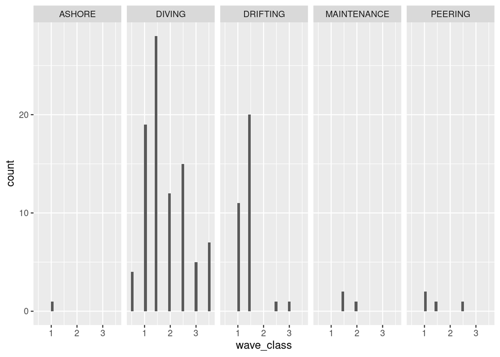

```r
loons_2023 %>%
 ggplot(aes(x = wave_class)) +
  geom_histogram() +
  facet_wrap(~ behavior, nrow = 1)
```

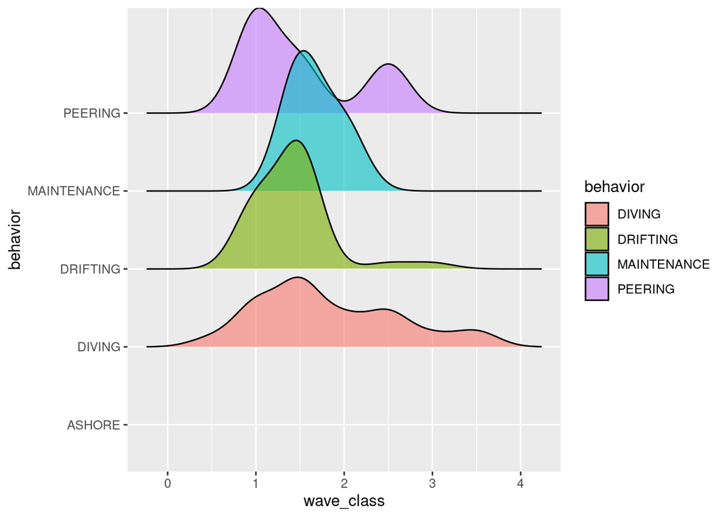

```r
loons_2023 %>%
  ggplot(aes(x = wave_class, y = behavior, fill = behavior)) +
  geom_density_ridges(alpha = 0.6, bins = 1)
```

### Statistics

```r
waveclassaov = aov(wave_class ~ behavior, data = loons_2023)
summary(waveclassaov)
```

```
##              Df Sum Sq Mean Sq F value Pr(>F)
## behavior      4   4.79  1.1975   2.356 0.0572 .
## Residuals   126  64.05  0.5083
## ---
## Signif. codes:  0 '***' 0.001 '**' 0.01 '*' 0.05 '.' 0.1 ' ' 1
```

Wave class did not significantly affect *G. immer* behavior (one-way ANOVA, F_4,126 = 2.356, P = 0.0572).

## Meters Offshore and Dive Times

Hypothesis: Distance from shore will significantly affect *G. immer* dive times.

Null Hypothesis: Distance from shore will not significantly affect *G. immer* dive times.

### Visualizations

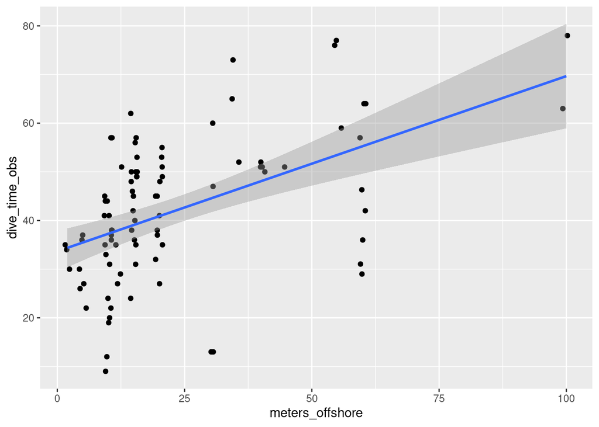

```r
loons_dive_2024 <- loons_2024 %>%
  filter(species == "common_loon") %>%
  select(tide, behavior, dive_time_obs, tidal_height, meters_offshore) %>%
  filter(dive_time_obs != "n/a") %>%
  filter(dive_time_obs != "na")

loons_dive_2024 <- loons_dive_2024 %>%
  separate_longer_delim(dive_time_obs, delim = ",") %>%
  mutate(dive_time_obs = as.numeric(dive_time_obs))

loons_dive_2024 %>%
  ggplot(aes(x = meters_offshore, y = dive_time_obs)) +
  geom_jitter() +
  geom_smooth(method = "lm")
```

### Statistics

```r
#linear model
loon.dive.meters.lm <- lm(dive_time_obs ~ meters_offshore, data = loons_dive_2024)

summary(loon.dive.meters.lm)
```

```
##
## Call:
## lm(formula = dive_time_obs ~ meters_offshore, data = loons_dive_2024)
##
## Residuals:
##     Min      1Q  Median      3Q     Max
## -31.472  -7.373   1.128   8.527  26.728
##
## Coefficients:
##                 Estimate Std. Error t value Pr(>|t|)
## (Intercept)     33.67113    2.10711  15.980  < 2e-16 ***
## meters_offshore  0.36003    0.06827   5.274  9.3e-07 ***
## ---
## Signif. codes:  0 '***' 0.001 '**' 0.01 '*' 0.05 '.' 0.1 ' ' 1
##
## Residual standard error: 13.07 on 89 degrees of freedom
##   (2 observations deleted due to missingness)
## Multiple R-squared:  0.2381, Adjusted R-squared:  0.2295
## F-statistic: 27.81 on 1 and 89 DF,  p-value: 9.298e-07
```

A linear model demonstrated a significant positive relationship between dive time and meters off shore (F1,89 = 27.81 : p = <0.5). 24% of the total variability in dive time can be predicted through a knowledge of meters off shore.

## Tidal height and dive times

Hypothesis: Tidal height will significantly affect *G. immer* dive times.

Null Hypothesis: Tidal height will not significantly affect *G. immer* dive times.

### Visualizations

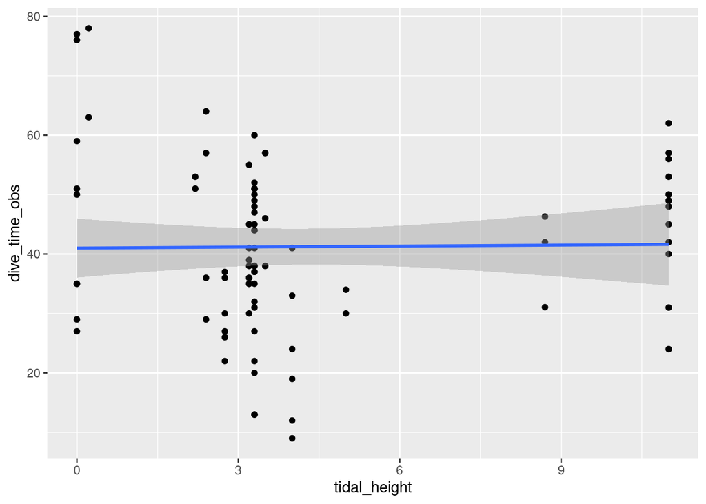

```r
loons_dive_2024 %>%
  ggplot(aes(x = tidal_height, y = dive_time_obs)) +
  geom_point() +
  geom_smooth(method = "lm")
```

### Statistics

```r
dive_time_tide_height_lm <- lm(dive_time_obs ~ tidal_height, data = loons_dive_2024)
summary(dive_time_tide_height_lm)
```

```
##
## Call:
## lm(formula = dive_time_obs ~ tidal_height, data = loons_dive_2024)
##
## Residuals:
##     Min      1Q  Median      3Q     Max
## -32.224  -9.935  -0.204   9.611  36.985
##
## Coefficients:
##              Estimate Std. Error t value Pr(>|t|)
## (Intercept)  41.00240    2.49655  16.424   <2e-16 ***
## tidal_height  0.05531    0.46486   0.119    0.906
## ---
## Signif. codes:  0 '***' 0.001 '**' 0.01 '*' 0.05 '.' 0.1 ' ' 1
##
## Residual standard error: 14.48 on 88 degrees of freedom
##   (3 observations deleted due to missingness)
## Multiple R-squared:  0.0001609,  Adjusted R-squared:  -0.0112
## F-statistic: 0.01416 on 1 and 88 DF,  p-value: 0.9056
```

```r
#This is actually so interesting
```

A linear model demonstrated no significant relationship between dive time and tidal height (F1,88 = 0.014 : p = 0.91).

## Tidal classification and dive times

Hypothesis: Tidal class will significantly affect *G. immer* dive times.

Null Hypothesis: Tidal class will not significantly affect *G. immer* dive times.

### Visualizations

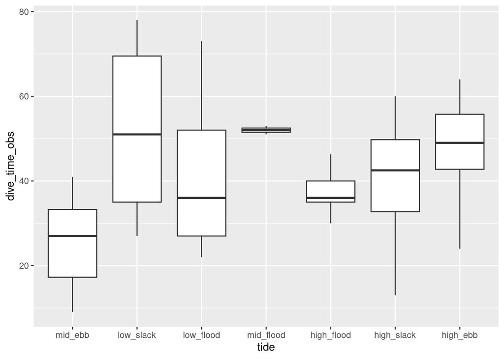

```r
loons_dive_2024$tide <- fct_relevel(loons_dive_2024$tide, c("mid_ebb",
                                                            "low_slack",
                                                            "low_flood",
                                                            "mid_flood",
                                                            "high_flood",
                                                            "high_slack",
                                                            "high_ebb"))
loons_dive_2024 %>%
ggplot(mapping = aes(x = tide, y = dive_time_obs)) +
  geom_boxplot()
```

### Statistics

```r
full_tide_aov = aov(dive_time_obs ~ tide, data = loons_dive_2024)
summary(full_tide_aov)
```

```
##             Df Sum Sq Mean Sq F value   Pr(>F)
## tide         6   4884     814   4.599 0.000427 ***
## Residuals   86  15220     177
## ---
## Signif. codes:  0 '***' 0.001 '**' 0.01 '*' 0.05 '.' 0.1 ' ' 1
```

```r
TukeyHSD(full_tide_aov)
```

```
##   Tukey multiple comparisons of means
##     95% family-wise confidence level
##
## Fit: aov(formula = dive_time_obs ~ tide, data = loons_dive_2024)
##
## $tide
##                              diff        lwr        upr     p adj
## low_slack-mid_ebb      27.4772727   8.813496 46.1410497 0.0005055
## low_flood-mid_ebb      15.6388889  -3.878526 35.1563034 0.2033536
## mid_flood-mid_ebb      26.7500000  -5.004412 58.5044124 0.1571289
## high_flood-mid_ebb     11.9654545  -6.698322 30.6292315 0.4629341
## high_slack-mid_ebb     14.3166667  -1.666037 30.2993704 0.1095394
## high_ebb-mid_ebb       22.5227273   5.939526 39.1059283 0.0017457
## low_flood-low_slack   -11.8383838 -29.891886  6.2151188 0.4348736
## mid_flood-low_slack    -0.7272727 -31.603513 30.1489673 1.0000000
## high_flood-low_slack  -15.5118182 -32.638875  1.6152382 0.1021039
## high_slack-low_slack  -13.1606061 -27.318512  0.9973001 0.0858958
## high_ebb-low_slack     -4.9545455 -19.787011  9.8779205 0.9507456
## mid_flood-low_flood    11.1111111 -20.288492 42.5107145 0.9355904
## high_flood-low_flood   -3.6734343 -21.726937 14.3800683 0.9961944
## high_slack-low_flood   -1.3222222 -16.587844 13.9433994 0.9999721
## high_ebb-low_flood      6.8838384  -9.009397 22.7770741 0.8465552
## high_flood-mid_flood  -14.7845455 -45.660785 16.0916945 0.7753709
## high_slack-mid_flood  -12.4333333 -41.766803 16.9001364 0.8593207
## high_ebb-mid_flood     -4.2272727 -33.892205 25.4376591 0.9994892
## high_slack-high_flood   2.3512121 -11.806694 16.5091183 0.9987762
## high_ebb-high_flood    10.5572727  -4.275193 25.3897387 0.3341765
## high_ebb-high_slack     8.2060606  -3.068348 19.4804694 0.3077188
```

An Analysis of Variance test demonstrated that tidal class has a significant effect on the length of *G. immer* dive times (ANOVA, F_6,86 = 4.599; p = 0.000427). An uplanned analytical comparison demonstrated that *G. immer* dive times at low slack tide were signficantly different than those at mid ebb tide (TukeyB, p < 0.0005055), and dive lengths at high ebb tide were significantly different than those at mid ebb tide (TukeyB, p = 0.0017457). Otherwise, there were no significant differences in dive times between other tidal classes (TukeyB, p > 0.05)

# Citations

Bent, A. C. 2009. Life Histories of North American Diving Birds. Cornell University Press: Ithaca, New York.

Daub, B. C. 1989. Behavior of Common Loons in Winter. Journal of Field Ornithology 60: 305-311.

Ford, T. B. and Gieg, J. A. 1995. Winter Behavior of the Common Loon. Journal of Field Ornithology 66: 22-29.

McIntyre, J. W. 1978. Wintering Behavior of Common Loons. The Auk 95: 396-403.

Holm, K. and Burger, A. 2002. Foraging Behavior and Resource Partitioning by Diving Birds During Winter in Areas of Strong Tidal Currents. Waterbirds 25(3): 312-325.

Thompson, Stephanie A. & Price, J. J. (2006). Water Clarity and Diving Behavior in Wintering Common Loons. Waterbirds: The International Journal of Waterbird Biology, 29(2), 169–175.